# Fitness Tracker data analysis

## Introduction and background

This is a simple analysis performed to discover key trends in fitness tracker market

#### Upload CSV files to R

Files used for analysis uploaded from kaggle: https://www.kaggle.com/arashnic/fitbit

#### Installing and loading common packages and libraries

```r
library(tidyverse)
library(readr)
```

#### Loading CSV files

creating a dataframe called “daily_activity” to upload specific data for analysis from “Fitabase Data 4.12.16-5.12.16”.

```r
daily_activity <- read.csv("dailyActivity_merged.csv")
```

creating another dataframe called “sleep_day” to upload more data

```r
sleep_day <- read.csv("sleepDay_merged.csv")
```

#### Exploring data

Taking a look at the daily_activity data.

```r
head(daily_activity)
```

```
##           Id ActivityDate TotalSteps TotalDistance TrackerDistance
## 1 1503960366    4/12/2016      13162          8.50            8.50
## 2 1503960366    4/13/2016      10735          6.97            6.97
## 3 1503960366    4/14/2016      10460          6.74            6.74
## 4 1503960366    4/15/2016       9762          6.28            6.28
## 5 1503960366    4/16/2016      12669          8.16            8.16
## 6 1503960366    4/17/2016       9705          6.48            6.48
##   LoggedActivitiesDistance VeryActiveDistance ModeratelyActiveDistance
## 1                        0               1.88                     0.55
## 2                        0               1.57                     0.69
## 3                        0               2.44                     0.40
## 4                        0               2.14                     1.26
## 5                        0               2.71                     0.41
## 6                        0               3.19                     0.78
##   LightActiveDistance SedentaryActiveDistance VeryActiveMinutes
## 1                6.06                       0                25
## 2                4.71                       0                21
## 3                3.91                       0                30
## 4                2.83                       0                29
## 5                5.04                       0                36
## 6                2.51                       0                38
##   FairlyActiveMinutes LightlyActiveMinutes SedentaryMinutes Calories
## 1                  13                  328              728     1985
## 2                  19                  217              776     1797
## 3                  11                  181             1218     1776
## 4                  34                  209              726     1745
## 5                  10                  221              773     1863
## 6                  20                  164              539     1728
```

Identifying all the columns in the daily_activity data.

```r
colnames(daily_activity)
```

```
##  [1] "Id"                       "ActivityDate"
##  [3] "TotalSteps"               "TotalDistance"
##  [5] "TrackerDistance"          "LoggedActivitiesDistance"
##  [7] "VeryActiveDistance"       "ModeratelyActiveDistance"
##  [9] "LightActiveDistance"      "SedentaryActiveDistance"
## [11] "VeryActiveMinutes"        "FairlyActiveMinutes"
## [13] "LightlyActiveMinutes"     "SedentaryMinutes"
## [15] "Calories"
```

Taking a look at the sleep_day data.

```r
head(sleep_day)
```

```
##           Id              SleepDay TotalSleepRecords TotalMinutesAsleep
## 1 1503960366 4/12/2016 12:00:00 AM                 1                327
## 2 1503960366 4/13/2016 12:00:00 AM                 2                384
## 3 1503960366 4/15/2016 12:00:00 AM                 1                412
## 4 1503960366 4/16/2016 12:00:00 AM                 2                340
## 5 1503960366 4/17/2016 12:00:00 AM                 1                700
## 6 1503960366 4/19/2016 12:00:00 AM                 1                304
##   TotalTimeInBed
## 1            346
## 2            407
## 3            442
## 4            367
## 5            712
## 6            320
```

```r
colnames(sleep_day)
```

```
## [1] "Id"                 "SleepDay"           "TotalSleepRecords"
## [4] "TotalMinutesAsleep" "TotalTimeInBed"
```

both datasets have the ‘Id’ field - this can be used to merge the datasets.

#### Understanding some summary statistics

first, identifying the unique participants in each dataframe

```r
n_distinct(daily_activity$Id)
```

```
## [1] 33
```

```r
n_distinct(sleep_day$Id)
```

```
## [1] 24
```

next how many observations are there in each dataframe?

```r
nrow(daily_activity)
```

```
## [1] 940
```

```r
nrow(sleep_day)
```

```
## [1] 413
```

#### More detailed statistics summary

For the daily activity dataframe:

```r
daily_activity %>%
  select(TotalSteps,
         TotalDistance,
         SedentaryMinutes) %>%
  summary()
```

```
##    TotalSteps    TotalDistance    SedentaryMinutes
##  Min.   :    0   Min.   : 0.000   Min.   :   0.0
##  1st Qu.: 3790   1st Qu.: 2.620   1st Qu.: 729.8
##  Median : 7406   Median : 5.245   Median :1057.5
##  Mean   : 7638   Mean   : 5.490   Mean   : 991.2
##  3rd Qu.:10727   3rd Qu.: 7.713   3rd Qu.:1229.5
##  Max.   :36019   Max.   :28.030   Max.   :1440.0
```

For the sleep dataframe:

```r
sleep_day %>%
  select(TotalSleepRecords,
         TotalMinutesAsleep,
         TotalTimeInBed) %>%
  summary()
```

```
##  TotalSleepRecords TotalMinutesAsleep TotalTimeInBed
##  Min.   :1.000     Min.   : 58.0      Min.   : 61.0
##  1st Qu.:1.000     1st Qu.:361.0      1st Qu.:403.0
##  Median :1.000     Median :433.0      Median :463.0
##  Mean   :1.119     Mean   :419.5      Mean   :458.6
##  3rd Qu.:1.000     3rd Qu.:490.0      3rd Qu.:526.0
##  Max.   :3.000     Max.   :796.0      Max.   :961.0
```

from the summary, the participants walked an average of 7638 steps daily and slept for 7 hours on average

#### Plotting a few explorations

Now to look at the relationship between steps taken in a day and sedentary minutes. This could help inform us on customer market segments to market to.

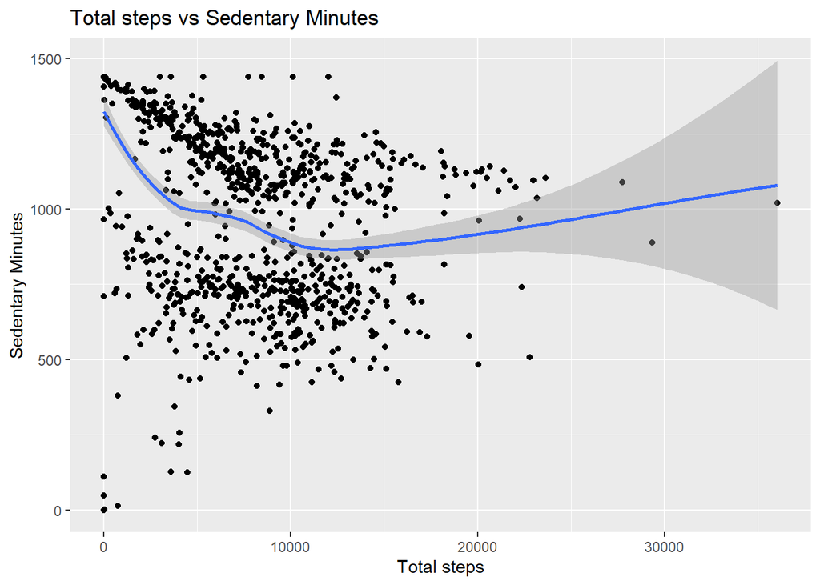

```r
ggplot(data=daily_activity, aes(x=TotalSteps, y=SedentaryMinutes)) + geom_point()+
  geom_smooth()+
  labs(title = "Total steps vs Sedentary Minutes", x = "Total steps", y = "Sedentary Minutes")
```

Next to look at the relationship between minutes asleep and time in bed.

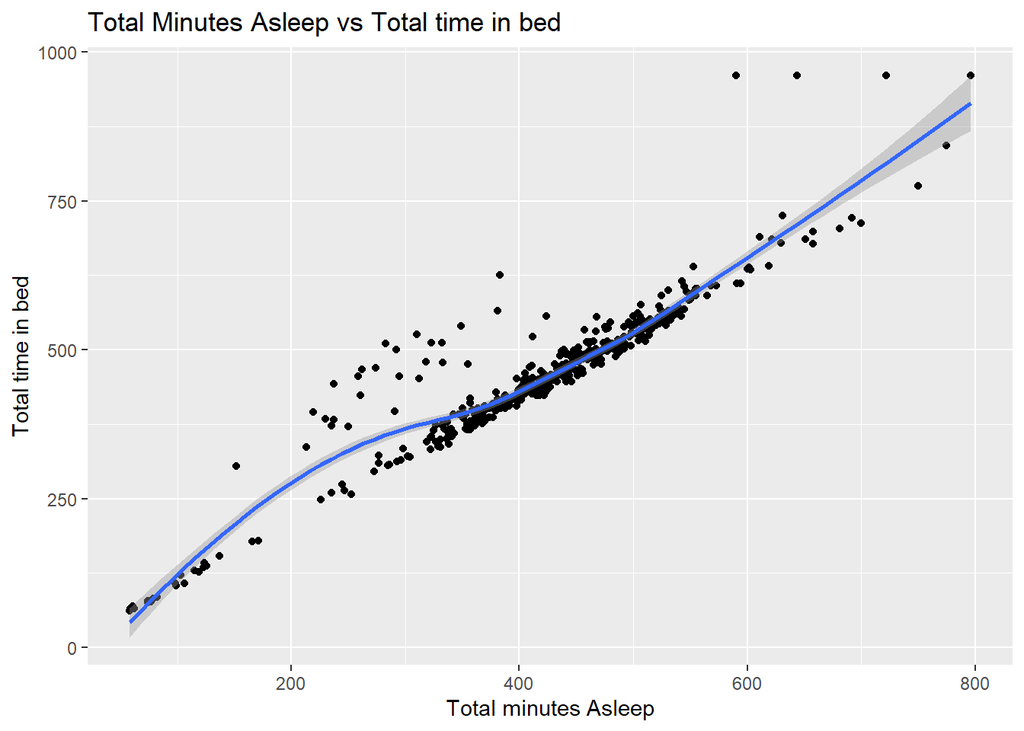

```r
ggplot(data=sleep_day, aes(x=TotalMinutesAsleep, y=TotalTimeInBed)) + geom_point()+
  geom_smooth()+
  labs(title = "Total Minutes Asleep vs Total time in bed", x = "Total minutes Asleep", y = "Total time in bed")
```

#### Merging these two datasets together

```r
combined_data <- merge(sleep_day, daily_activity, by="Id")
head(combined_data)
```

```
##           Id              SleepDay TotalSleepRecords TotalMinutesAsleep
## 1 1503960366 4/12/2016 12:00:00 AM                 1                327
## 2 1503960366 4/12/2016 12:00:00 AM                 1                327
## 3 1503960366 4/12/2016 12:00:00 AM                 1                327
## 4 1503960366 4/12/2016 12:00:00 AM                 1                327
## 5 1503960366 4/12/2016 12:00:00 AM                 1                327
## 6 1503960366 4/12/2016 12:00:00 AM                 1                327
##   TotalTimeInBed ActivityDate TotalSteps TotalDistance TrackerDistance
## 1            346     5/7/2016      11992          7.71            7.71
## 2            346     5/6/2016      12159          8.03            8.03
## 3            346     5/1/2016      10602          6.81            6.81
## 4            346    4/30/2016      14673          9.25            9.25
## 5            346    4/12/2016      13162          8.50            8.50
## 6            346    4/13/2016      10735          6.97            6.97
##   LoggedActivitiesDistance VeryActiveDistance ModeratelyActiveDistance
```

[output cut: 20 more lines]

#### A summary of combined_data

```r
head(combined_data)
```

```
##           Id              SleepDay TotalSleepRecords TotalMinutesAsleep
## 1 1503960366 4/12/2016 12:00:00 AM                 1                327
## 2 1503960366 4/12/2016 12:00:00 AM                 1                327
## 3 1503960366 4/12/2016 12:00:00 AM                 1                327
## 4 1503960366 4/12/2016 12:00:00 AM                 1                327
## 5 1503960366 4/12/2016 12:00:00 AM                 1                327
## 6 1503960366 4/12/2016 12:00:00 AM                 1                327
##   TotalTimeInBed ActivityDate TotalSteps TotalDistance TrackerDistance
## 1            346     5/7/2016      11992          7.71            7.71
## 2            346     5/6/2016      12159          8.03            8.03
## 3            346     5/1/2016      10602          6.81            6.81
## 4            346    4/30/2016      14673          9.25            9.25
## 5            346    4/12/2016      13162          8.50            8.50
## 6            346    4/13/2016      10735          6.97            6.97
##   LoggedActivitiesDistance VeryActiveDistance ModeratelyActiveDistance
```

[output cut: 20 more lines]

```r
colnames(combined_data)
```

```
##  [1] "Id"                       "SleepDay"
##  [3] "TotalSleepRecords"        "TotalMinutesAsleep"
##  [5] "TotalTimeInBed"           "ActivityDate"
##  [7] "TotalSteps"               "TotalDistance"
##  [9] "TrackerDistance"          "LoggedActivitiesDistance"
## [11] "VeryActiveDistance"       "ModeratelyActiveDistance"
## [13] "LightActiveDistance"      "SedentaryActiveDistance"
## [15] "VeryActiveMinutes"        "FairlyActiveMinutes"
## [17] "LightlyActiveMinutes"     "SedentaryMinutes"
## [19] "Calories"
```

```r
combined_data %>%
  select(TotalSteps, TotalDistance, Calories, SedentaryMinutes, VeryActiveMinutes, TotalTimeInBed, TotalMinutesAsleep) %>%
  summary()
```

```
##    TotalSteps    TotalDistance       Calories    SedentaryMinutes
##  Min.   :    0   Min.   : 0.000   Min.   :   0   Min.   :   0.0
##  1st Qu.: 4660   1st Qu.: 3.180   1st Qu.:1783   1st Qu.: 659.0
##  Median : 8596   Median : 6.120   Median :2162   Median : 734.0
##  Mean   : 8117   Mean   : 5.735   Mean   :2329   Mean   : 799.2
##  3rd Qu.:11317   3rd Qu.: 7.920   3rd Qu.:2865   3rd Qu.: 853.0
##  Max.   :22988   Max.   :17.950   Max.   :4900   Max.   :1440.0
##  VeryActiveMinutes TotalTimeInBed  TotalMinutesAsleep
##  Min.   :  0.00    Min.   : 61.0   Min.   : 58.0
##  1st Qu.:  0.00    1st Qu.:402.0   1st Qu.:361.0
##  Median :  8.00    Median :463.0   Median :432.0
##  Mean   : 23.97    Mean   :458.4   Mean   :419.4
##  3rd Qu.: 36.00    3rd Qu.:526.0   3rd Qu.:492.0
##  Max.   :210.00    Max.   :961.0   Max.   :796.0
```

Taking a look at how many participants are in this data set.

```r
n_distinct(combined_data$Id)
```

```
## [1] 24
```

# Plotting a few more Explorations

Looking at the relationship between daily steps and daily calories

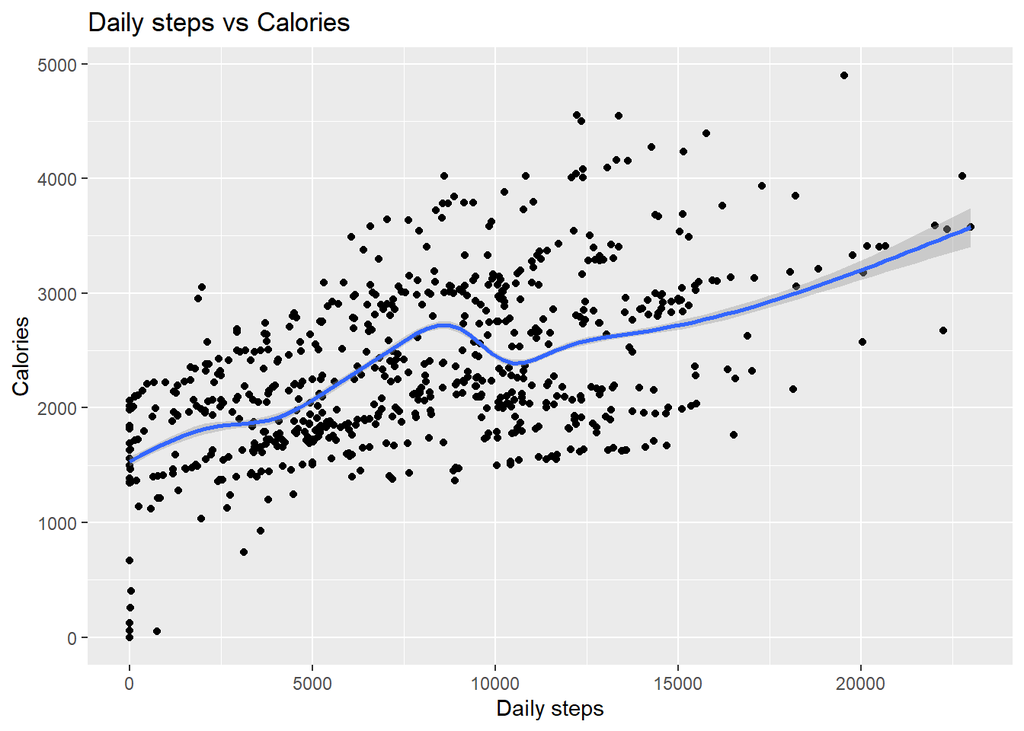

```r
ggplot(combined_data, aes(x = TotalSteps, y = Calories))+
  geom_point()+
  geom_smooth()+
  labs(title = "Daily steps vs Calories", x = "Daily steps", y = "Calories")
```

Now a look at the relationship between daily exercise time(VeryActiveMinutes) and calories

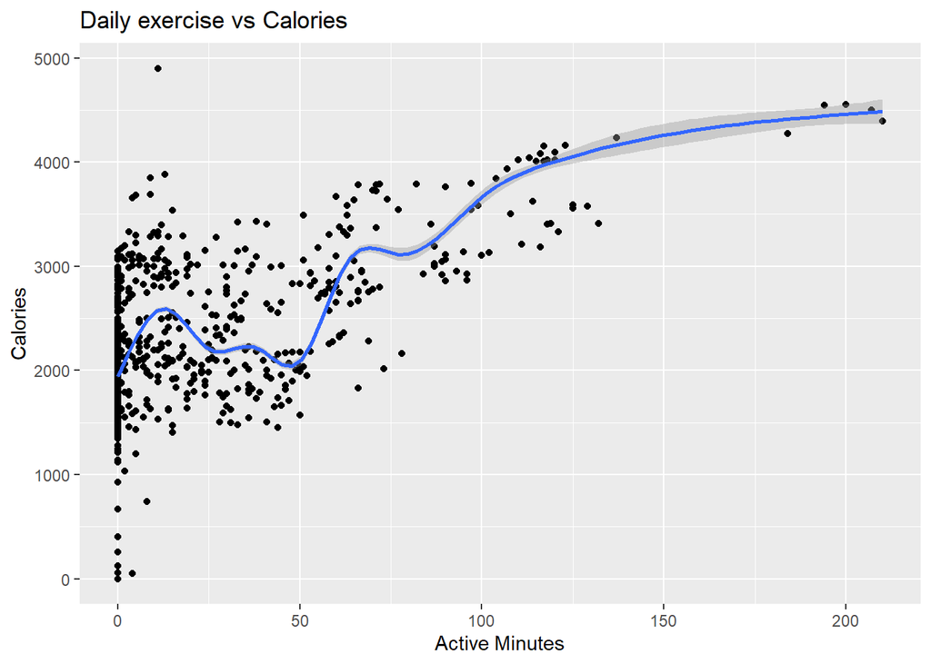

```r
ggplot(combined_data, aes(x = VeryActiveMinutes, y = Calories))+
  geom_point()+
  geom_smooth()+
  labs(title = "Daily exercise vs Calories", x = "Active Minutes", y = "Calories")
```

Now a look at the relationship between daily sleep and calories

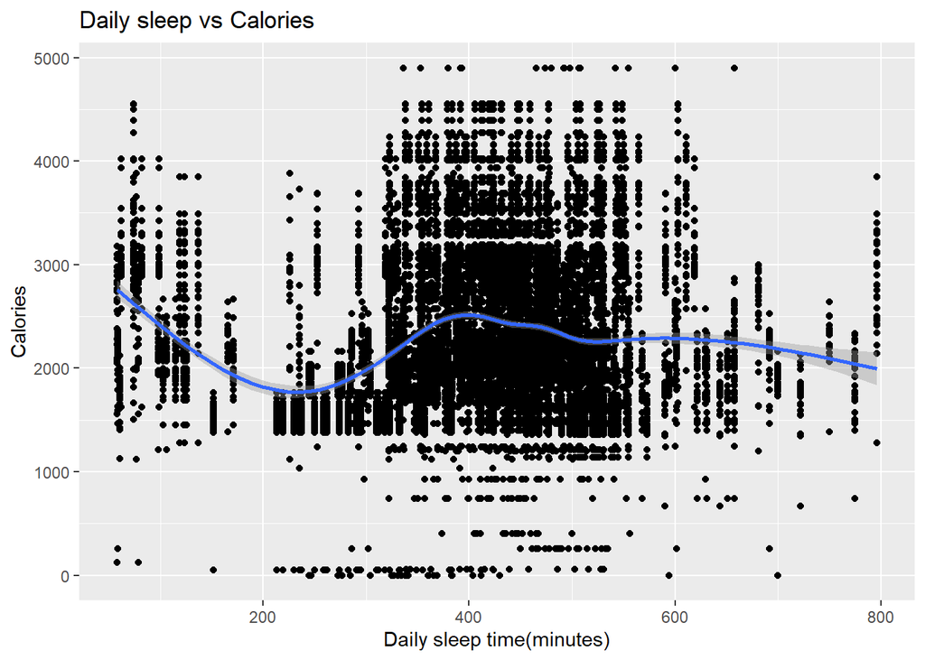

```r
ggplot(combined_data, aes(x = TotalMinutesAsleep, y = Calories))+
  geom_point()+
  geom_smooth()+
  labs(title = "Daily sleep vs Calories", x = "Daily sleep time(minutes)", y = "Calories")
```